# Otus centrales de tomate según muestras divididas

2023-09-27

Para determinar la validez de los resultados sobre OTUs clave analizados en “./analisis_de_otus_clave.Rmd” se reprodujo el algoritmo del script “first_analysis.R” sobre submuestreos de las muestras de rizósfera de tomate. Se tomaron esas muestras por ser las más abundantes (22). Los primeros submuestreos fueron por metadatos y los siguientes fueron aleatorios. En cada uno de los casos se construyó una red de correlación de Spearman, y a cada una de las redes se le aplicó el script “first_analysis.R”.

En este archivo se analizan los reportes de OTUs clave de cada una de los submuestreos y se contrastan con los originales.

#Paquetes y funciones auxiliares

```r
if (!require("BiocManager", quietly = TRUE))
    install.packages("BiocManager")
if (!require(vegan)) install.packages('vegan')
```

```r
library(vegan)
if (!require(igraph)) install.packages('igraph')
library(igraph)
if (!require(apcluster)) install.packages('apcluster')
library(apcluster)
if (!require(plyr)) install.packages('plyr')
library(plyr)
if (!require(stringr)) install.packages('stringr')
library(stringr)
if (!require(phyloseq)) install.packages('phyloseq')
library(phyloseq)
if (!require(UpSetR)) install.packages('UpSetR')
library(UpSetR)
```

```r
lista_nombres <- function(lista_taxa , rango){
  nombres_rango <- c()
  for (i in 1:length(lista_taxa)) {
    nombres_rango <- union(nombres_rango , as.vector(lista_taxa[[i]][ , rango]))
  }
  return(nombres_rango)
}
```

```r
matriz_incidencia <- function(lista_nombres , lista_taxa , rango){
  matriz <- matrix( nrow = length(lista_nombres), ncol = length(lista_taxa) )

  for (i in 1:length(lista_taxa)){
  for (j in 1:length(lista_nombres)) {
    if (is.element(lista_nombres[j], as.vector(lista_taxa[[i]][, rango] ))){
      matriz[j,i] <- 1
    }else
    {
      matriz[j,i] <- 0
    }
  }

  }


df <- data.frame(matriz , row.names = lista_nombres )
return(df)
}
```

#Muestras divididas según “Desarrollo” o “No desarrollo”

Los metadatos proporcionados que etiquetaban a las muestras en “Desarrollo”, “Por transplantar”, “Llenado de Fruto”, “Produccion”. Del total, 14 tienen la etiqueta de “Desarrollo”. Siendo estas mu,estras más de la mitad de las totales las muestras se dividieron en “Desarrollo” y “No desarrollo” (8 muestras).

En esta sección se hace el contraste entre los resultados provenientes de todas las muestras de rizósfera de tomate con los provenientes de las muestras de “Desarrollo” y las de “No desarrollo”. En las siguientes tres celdas se toman los tres reportes de OTUs centrales y los datos taxonómicos de las bacterias presentes en todas las muestras de rizósfera de tomate.

```r
muestras_tomate <- c("desarrollo" , "no_desarrollo" , "totales")
```

```r
otus_tomate_desarrollo <- read.csv("../central_otus/otus_centrales_tomate_desarrollo" , row.names = 1)
otus_tomate_no_desarrollo <- read.csv("../central_otus/otus_centrales_tomate_no_desarrollo.csv" , row.names = 1)
otus_tomate_totales <- read.csv("../central_otus/reporte_tomate1.csv" , row.names = 1)

otus_centrales_tomate2 <- list(otus_tomate_desarrollo , otus_tomate_no_desarrollo , otus_tomate_totales)
```

```r
rizosfera_bacterias <- read.csv("../../data/taxonomy/linaje_bacterias_standarizado.de_tomate.csv" , header = FALSE , sep = ";" , row.names = 1)
```

La cantidad de OTUs clave en cada uno de los casos fue de 2 a 4 veces la cantidad de muestras correspondientes.

```r
taxa_centrales_tomate <- list()
for (i in 1:3){
  taxa_centrales_tomate[[i]] <- rizosfera_bacterias[intersect( row.names(rizosfera_bacterias), row.names(otus_centrales_tomate2[[i]])),]
  print( paste0( "Se obtuvieron "  , length(row.names(otus_centrales_tomate2[[i]])) , " OTUs clave en las " , length(colnames(otus_centrales_tomate2[[i]]))-4 , " muestras de " , muestras_tomate[i] ) )
}
```

```
## [1] "Se obtuvieron 54 OTUs clave en las 14 muestras de desarrollo"
## [1] "Se obtuvieron 24 OTUs clave en las 8 muestras de no_desarrollo"
## [1] "Se obtuvieron 37 OTUs clave en las 18 muestras de totales"
```

##Coincidencias por familia y género

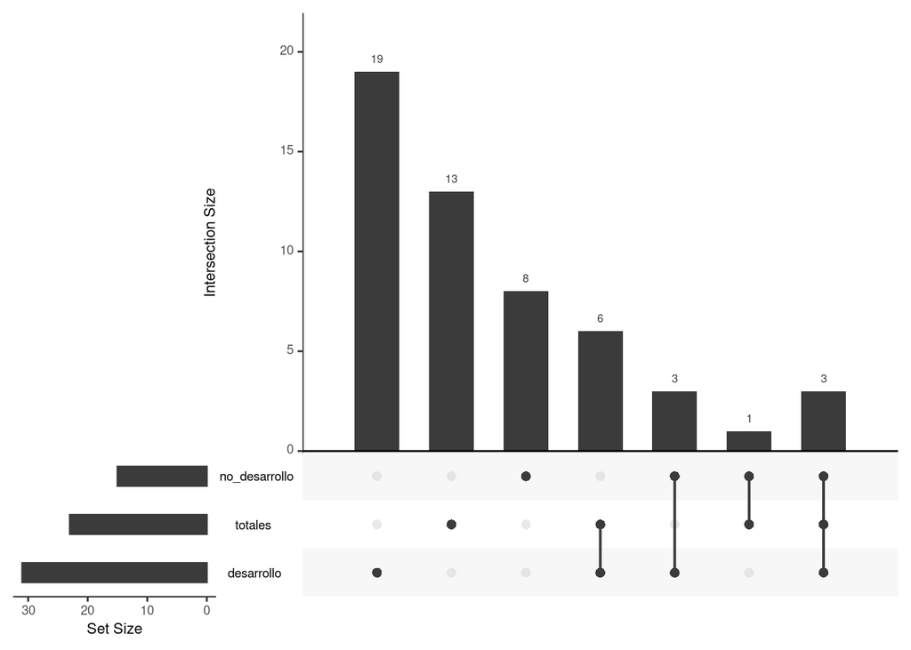

```r
nombres_familias <- lista_nombres(taxa_centrales_tomate, "V7")
data_familias <- matriz_incidencia(nombres_familias , taxa_centrales_tomate , "V7")

colnames(data_familias) <- muestras_tomate
upset(data_familias    )
```

Pseudomonadaceae, Micrococcaceae y Mycobacteriaceae son las tres familias que se encontraron en los tres analisis.

```r
interseccion_familias <- intersect(as.vector(taxa_centrales_tomate[[1]][,"V7"]) , as.vector(taxa_centrales_tomate[[2]][,"V7"]))
interseccion_familias <- intersect(interseccion_familias , as.vector(taxa_centrales_tomate[[3]][,"V7"]))
print(interseccion_familias)
```

```
## [1] "Pseudomonadaceae" "Micrococcaceae"   "Mycobacteriaceae"
```

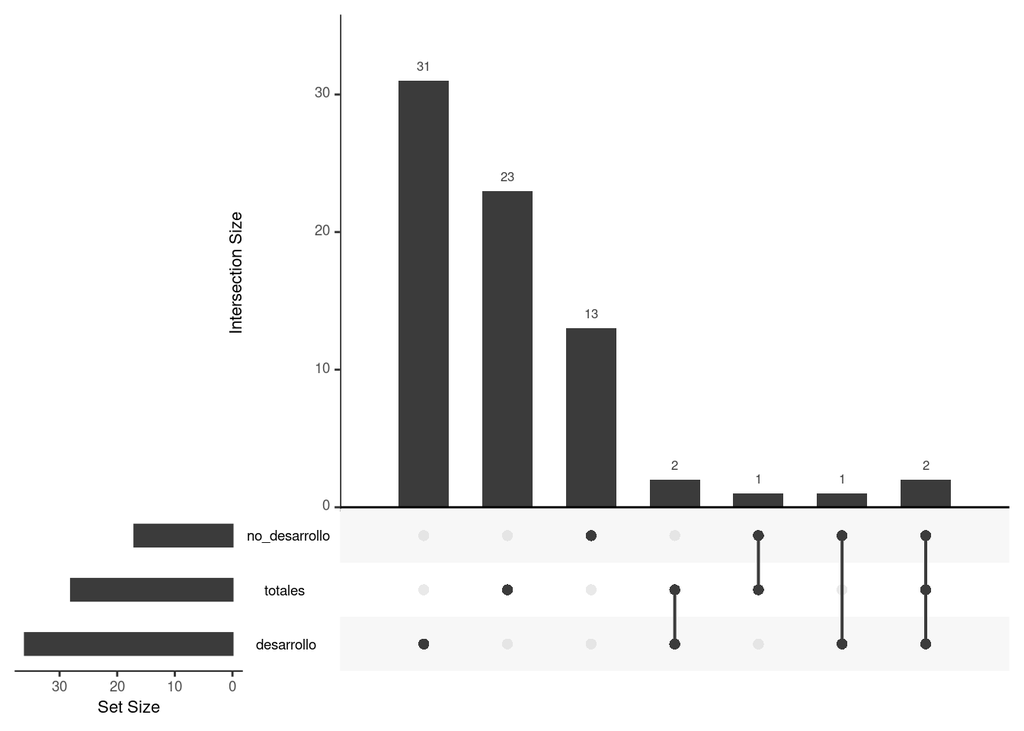

```r
nombres_generos <- lista_nombres(taxa_centrales_tomate, "V8")
data_generos <- matriz_incidencia(nombres_generos , taxa_centrales_tomate , "V8")

colnames(data_generos) <- muestras_tomate
upset(data_generos)
```

Los géneros presentes entre los OTUs clave de los tres análisis son Pseudomonas y Halopseudomonas.

```r
interseccion_generos <- intersect(as.vector(taxa_centrales_tomate[[1]][,"V8"]) , as.vector(taxa_centrales_tomate[[2]][,"V8"]))
interseccion_generos <- intersect(interseccion_generos, as.vector(taxa_centrales_tomate[[3]][,"V8"]))
print(interseccion_generos)
```

```
## [1] "Pseudomonas"     "Halopseudomonas"
```

```r
data_tomate_desarrollo <- read.csv("../../data/tables/tomate_desarrollo.csv" , row.names = 1, header = TRUE )

medias <- c()
medianas <- c()
for (i in 1:dim(data_tomate_desarrollo)[2]){
  medias <- c(medias , mean(data_tomate_desarrollo[ , i]))
  medianas <- c(medianas , median(data_tomate_desarrollo[ , i]))
  }

data_tomate_desarrollo <- data_tomate_desarrollo[ row.names(otus_centrales_tomate2[[1]]),]
data_tomate_desarrollo <- rbind(medias , data_tomate_desarrollo)
data_tomate_desarrollo <- rbind(medianas , data_tomate_desarrollo)

row.names(data_tomate_desarrollo) <- c("Medianas" , "Medias" , row.names(otus_centrales_tomate2[[1]]))
head(data_tomate_desarrollo)
```

```
##          vcXtM2TOMPOOB050180.extra.kraken2.report
## Medianas                                  10.0000
## Medias                                   391.4365
## 1479019                                  236.0000
## 299262                                   334.0000
## 1858609                                  346.0000
## 1658672                                  520.0000
##          iYASM2TOMPOOA050195.extra.kraken2.report
## Medianas                                   8.0000
## Medias                                   259.9861
## 1479019                                  197.0000
## 299262                                   279.0000
## 1858609                                  241.0000
## 1658672                                  329.0000
##          XR8LM2TOMPOOB051125.extra.kraken2.report
## Medianas                                   7.0000
## Medias                                   277.1592
## 1479019                                  183.0000
## 299262                                   220.0000
## 1858609                                  238.0000
## 1658672                                  313.0000
##          TECcM2TOMPOOA051310.extra.kraken2.report
## Medianas                                   7.0000
## Medias                                   261.6283
## 1479019                                  142.0000
## 299262                                   251.0000
## 1858609                                  215.0000
## 1658672                                  287.0000
##          FvY2M2TOMPOOB051329.extra.kraken2.report
## Medianas                                  11.0000
## Medias                                   346.1545
## 1479019                                  227.0000
## 299262                                   358.0000
## 1858609                                  485.0000
## 1658672                                  448.0000
##          abKIM2TOMPOOA051320.extra.kraken2.report
## Medianas                                   7.0000
## Medias                                   263.7405
## 1479019                                  170.0000
## 299262                                   198.0000
```

[output cut: 43 more lines]

```
## 1658672                                  566.0000
##          dSz8M2TOMPOOA051340.extra.kraken2.report
## Medianas                                    9.000
## Medias                                    366.653
## 1479019                                   232.000
## 299262                                    325.000
## 1858609                                   346.000
## 1658672                                   374.000
##          nG3jM2TOMPOOA051345.extra.kraken2.report
## Medianas                                   3.0000
## Medias                                   146.2994
## 1479019                                   89.0000
## 299262                                   127.0000
## 1858609                                  261.0000
## 1658672                                  168.0000
```

```r
data_tomate_no_desarrollo <- read.csv("../../data/tables/tomate_no_desarrollo.csv" , row.names = 1, header = TRUE )

medias <- c()
medianas <- c()
for (i in 1:dim(data_tomate_no_desarrollo)[2]){
  medias <- c(medias , mean(data_tomate_no_desarrollo[ , i]))
  medianas <- c(medianas , median(data_tomate_no_desarrollo[ , i]))
  }

data_tomate_no_desarrollo <- data_tomate_no_desarrollo[ row.names(otus_centrales_tomate2[[2]]),]
data_tomate_no_desarrollo <- rbind(medias , data_tomate_no_desarrollo)
data_tomate_no_desarrollo <- rbind(medianas , data_tomate_no_desarrollo)

row.names(data_tomate_no_desarrollo) <- c("Medianas" , "Medias" , row.names(otus_centrales_tomate2[[2]]))
head(data_tomate_no_desarrollo)
```

```
##          X0n7bM2TOMPOOA100365.extra.kraken2.report
## Medianas                                   13.0000
## Medias                                    414.1385
## 419610                                    198.0000
## 32009                                     185.0000
## 640081                                    280.0000
## 2706126                                   241.0000
##          X9JUZM2TOMPOOB100355.extra.kraken2.report
## Medianas                                   1.00000
## Medias                                    53.03212
## 419610                                    77.00000
## 32009                                     26.00000
## 640081                                    20.00000
## 2706126                                   25.00000
##          AYtCM2TOMPOOA100360.extra.kraken2.report
## Medianas                                   13.000
## Medias                                    512.154
## 419610                                    246.000
## 32009                                     188.000
## 640081                                    214.000
## 2706126                                   217.000
##          DYZgM2TOMPOOB100370.extra.kraken2.report
## Medianas                                   8.0000
## Medias                                   273.3938
## 419610                                   162.0000
## 32009                                    115.0000
## 640081                                   178.0000
## 2706126                                  157.0000
##          cSObM2TOMPOOM080315.extra.kraken2.report
## Medianas                                   7.0000
## Medias                                   304.5122
## 419610                                   122.0000
## 32009                                    108.0000
## 640081                                   172.0000
## 2706126                                  158.0000
##          wQqUM2TOMPOOA080335.extra.kraken2.report
## Medianas                                   5.0000
## Medias                                   271.2555
## 419610                                   116.0000
## 32009                                    104.0000
## 640081                                   261.0000
## 2706126                                  142.0000
##          X1qGgM2TOMPOOM080340.extra.kraken2.report
## Medianas                                    26.000
## Medias                                     923.291
## 419610                                     265.000
## 32009                                      229.000
## 640081                                     334.000
## 2706126                                    408.000
##          aFJgM2TOMPOOM090325.extra.kraken2.report
## Medianas                                   3.0000
## Medias                                   146.8886
## 419610                                    45.0000
## 32009                                     41.0000
## 640081                                    41.0000
## 2706126                                   52.0000
```

#Otus centrales según submuestreos aleatorios

Los siguientes 10 submuestreos fueron aleatorios de 11 muestras cada uno (la mitad).

```r
otus_tomate_aleatorio1 <- list()

for (i in 1:10){
  otus_tomate_aleatorio1[[i]] <- read.csv( paste0("../central_otus/otus_centrales_tomate_aleatorio1_" , as.character(i) , ".csv" ) , row.names = 1)
}
```

La cantidad de OTUs detectados como clave en los submuestreos aleaorios se encuentra en un rango similar a la de los OTUs detectados con todas las muestras y con la primera división no aleatoria (37, 54, 24).

```r
taxa_tomate_aleatorio1 <- list()
numero_otus <- c()
for (i in 1:10){
  taxa_tomate_aleatorio1[[i]] <- rizosfera_bacterias[ intersect(row.names(rizosfera_bacterias), row.names(otus_tomate_aleatorio1[[i]])),]
  x_i <-  length(row.names(otus_tomate_aleatorio1[[i]]))
  print( paste0( "Se obtuvieron "  , as.character(x_i)  , " OTUs centrales en el submuestreo aleatorio " , as.character(i)  ) )
  numero_otus <- c(numero_otus , x_i)
}
```

```
## [1] "Se obtuvieron 55 OTUs centrales en el submuestreo aleatorio 1"
## [1] "Se obtuvieron 49 OTUs centrales en el submuestreo aleatorio 2"
## [1] "Se obtuvieron 37 OTUs centrales en el submuestreo aleatorio 3"
## [1] "Se obtuvieron 43 OTUs centrales en el submuestreo aleatorio 4"
## [1] "Se obtuvieron 39 OTUs centrales en el submuestreo aleatorio 5"
## [1] "Se obtuvieron 31 OTUs centrales en el submuestreo aleatorio 6"
## [1] "Se obtuvieron 33 OTUs centrales en el submuestreo aleatorio 7"
## [1] "Se obtuvieron 41 OTUs centrales en el submuestreo aleatorio 8"
## [1] "Se obtuvieron 56 OTUs centrales en el submuestreo aleatorio 9"
## [1] "Se obtuvieron 83 OTUs centrales en el submuestreo aleatorio 10"
```

```r
print(paste0("Su media fue ", as.character(mean(numero_otus))))
```

```
## [1] "Su media fue 46.7"
```

```r
print(paste0("Su mediana fue ", as.character(median(numero_otus))))
```

```
## [1] "Su mediana fue 42"
```

```r
taxa_tomate_aleatorio1[[11]] <- taxa_centrales_tomate[[3]]
nombres_familias <- lista_nombres(taxa_tomate_aleatorio1 , "V7")
data_familias <- matriz_incidencia(nombres_familias , taxa_tomate_aleatorio1 , "V7")
colnames(data_familias) <- c(1:10 , "totales")
```

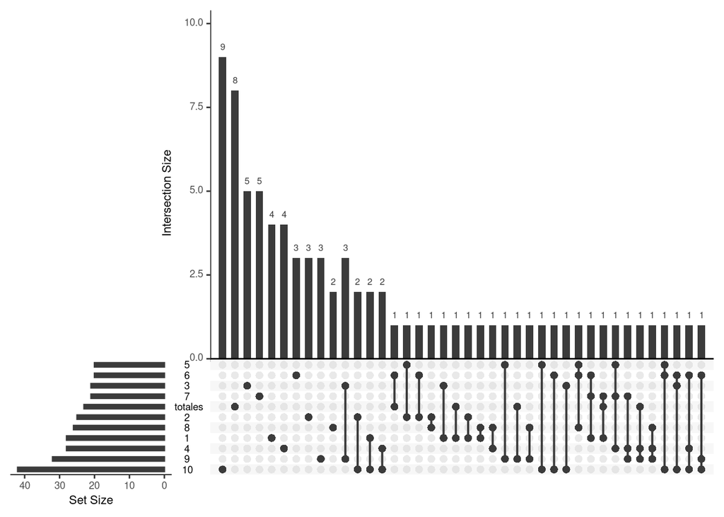

```r
upset(data_familias  , nsets = 11  )
```

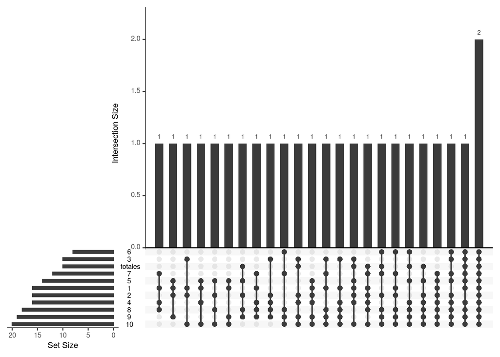

```r
familias_comunes <- c()
for (i in 1:106){
  if (sum(data_familias[i,])>3) {
    familias_comunes <- c(familias_comunes , i)} }

data_familias_comunes <- data_familias[ familias_comunes , ]
upset(data_familias_comunes , nsets = 11)
```

Acetobacteraceae y Pseudomonadaceae son las familias rescatadas en los 10 submuestreos aleatorios así como en el original. Burkholderiaceae solo no fue encontrado en uno de los analisis aleatorios. Corynebacteriaceae fue encnontrada en 9 de los análisis aleatorios, pero no el original. Enterobacteriaceae fue encontrado en 8 de los submuestreos aleatorios, pero no en el análisis original, aunque estaba presente en el de muestras de “desarrollo”.

```r
data_familias_comunes[ c("Acetobacteraceae","Pseudomonadaceae", "Burkholderiaceae" , "Corynebacteriaceae" , "Enterobacteriaceae") ,]
```

```
##                    1 2 3 4 5 6 7 8 9 10 totales
## Acetobacteraceae   1 1 1 1 1 1 1 1 1  1       1
## Pseudomonadaceae   1 1 1 1 1 1 1 1 1  1       1
## Burkholderiaceae   1 0 1 1 1 1 1 1 1  1       1
## Corynebacteriaceae 0 1 1 1 1 1 1 1 1  1       0
## Enterobacteriaceae 1 1 0 1 1 0 1 1 1  1       0
```

```r
nombres_generos <- lista_nombres(taxa_tomate_aleatorio1 , "V8")
data_generos <- matriz_incidencia(nombres_generos , taxa_tomate_aleatorio1 , "V8")
colnames(data_generos) <- c(1:10 , "totales")
```

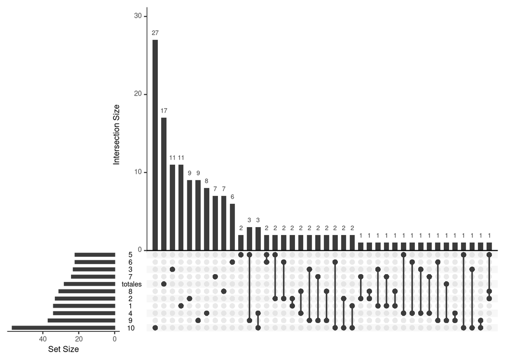

```r
upset(data_generos  , nsets = 11  )
```

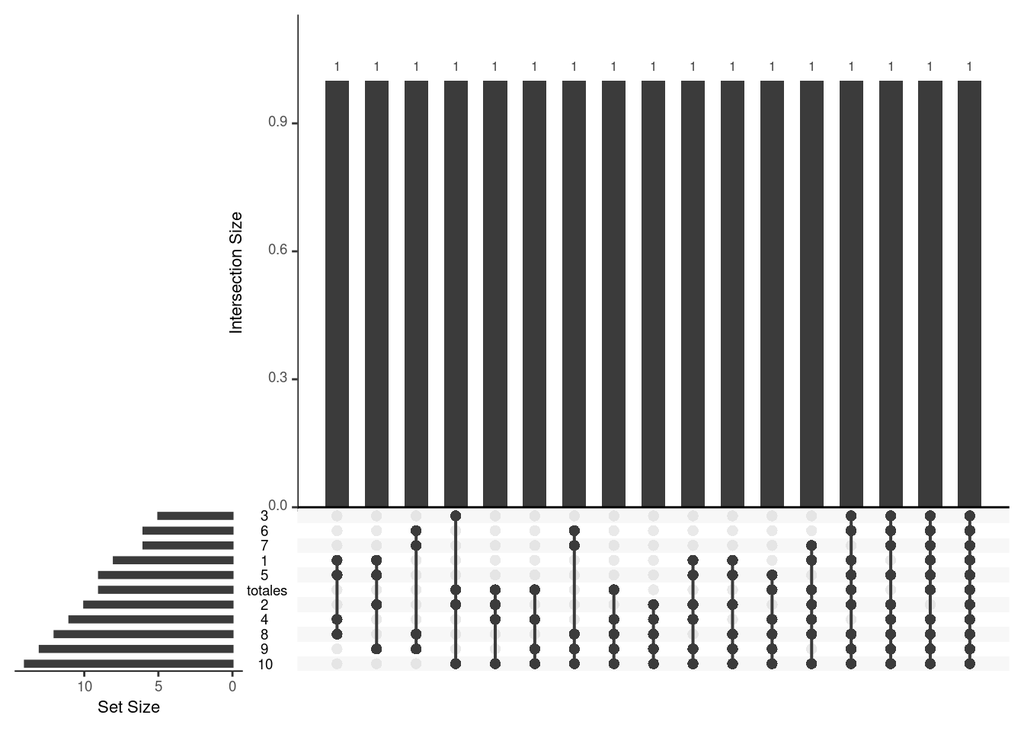

```r
generos_comunes <- c()
for (i in 1:188){
  if (sum(data_generos[i,])>3) {
    generos_comunes <- c(generos_comunes , i)} }

data_generos_comunes <- data_generos[ generos_comunes , ]
upset(data_generos_comunes , nsets = 11)
```

El género Pseudomonas fue considerado clave en cada uno de los submuestreos aleatorios. El genero Burkholderia apareció en todos salvo uno de los analisis aleatorios. El género Komagataeibacter reapareció en 8 de los muestreos aleatorios y el original. Corynebacterium apareció en 9 de los análisis aleatorios sin aparecer en el original, aunque sí aparece en el análisis de muestras de desarrollo.

```r
data_generos_comunes[ c("Pseudomonas", "Burkholderia" , "Corynebacterium" , "Komagataeibacter") ,]
```

```
##                  1 2 3 4 5 6 7 8 9 10 totales
## Pseudomonas      1 1 1 1 1 1 1 1 1  1       1
## Burkholderia     1 0 1 1 1 1 1 1 1  1       1
## Corynebacterium  0 1 1 1 1 1 1 1 1  1       0
## Komagataeibacter 1 1 1 0 1 1 0 1 1  1       1
```

```r
taxa_gen_comunes <- list()
for (i in 1:length(taxa_tomate_aleatorio1)){
  index_gen_comunes <- c()
  for (j in 1:(dim(taxa_tomate_aleatorio1[[i]])[1])) {
    if (is.element(taxa_tomate_aleatorio1[[i]][j,"V8"], c("Pseudomonas", "Burkholderia" , "Corynebacterium" , "Komagataeibacter")  )){
      index_gen_comunes <- c(index_gen_comunes , j)
    }
  }
  taxa_gen_comunes[[i]] <- taxa_tomate_aleatorio1[[i]][ index_gen_comunes , ]
}
```

```r
nombres_especies <- lista_nombres(taxa_gen_comunes , "V9")
data_especies <- matriz_incidencia(nombres_especies , taxa_gen_comunes , "V9")
colnames(data_especies) <- c(1:10 , "totales")
```

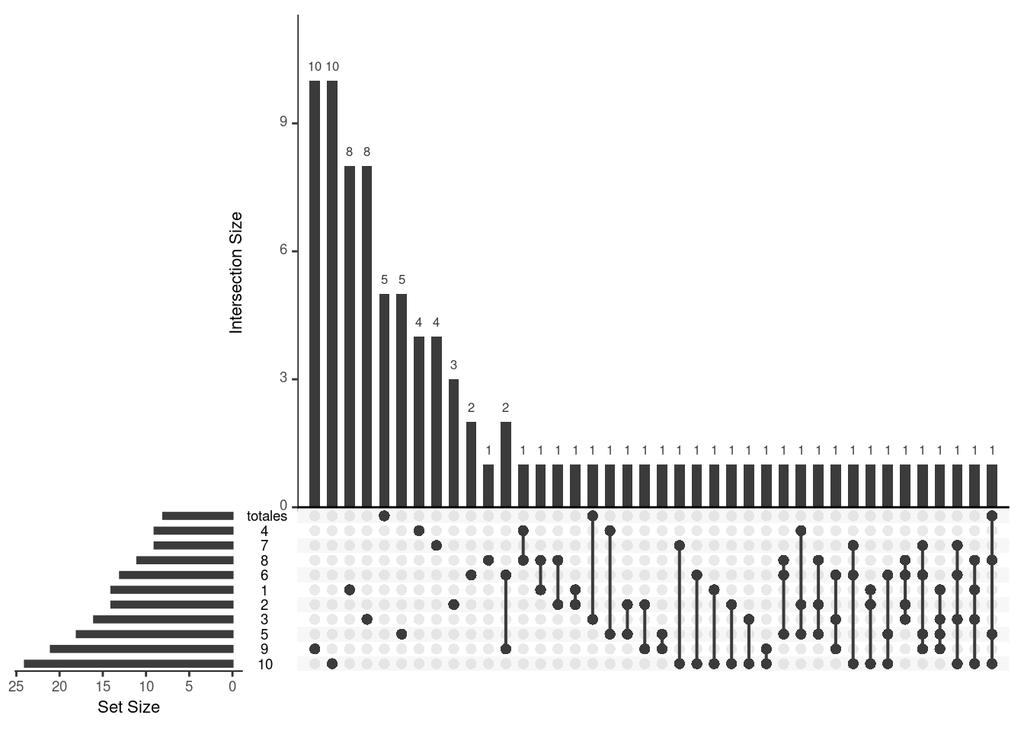

```r
upset(data_especies  , nsets = 11  )
```

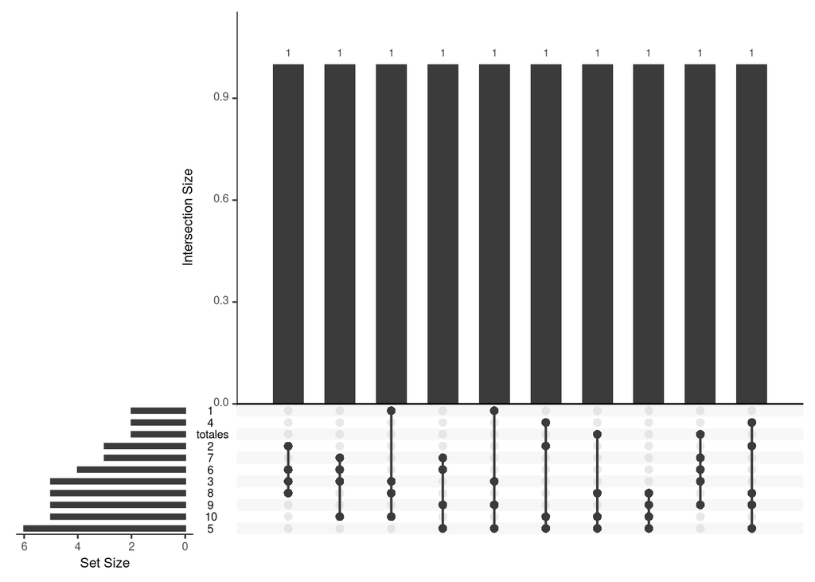

```r
especies_comunes <- c()
for (i in 1:94){
  if (sum(data_especies[i,])>3) {
    especies_comunes <- c(especies_comunes , i)} }

data_especies_comunes <- data_especies[ especies_comunes , ]
upset(data_especies_comunes , nsets = 11)
```

Del género Pseudomonas, la especie agaric fue encontrada como especie clave en todas las muestras, y fue encontrada en 4 de los submuetreos aleatorios. Del género Komagataeibacter, las dos especies clave más comunes entre los submuestreos aleatorios, Medellinensis y Europaeu, no aparecen en el análisis original. La especie clave del género Corynebacterium más común entre los submuestreos aleatorios fue glucoronolyticu, apareciendo en la mitad de ellos, aunque no en el análisis de las muestras de “desarrollo”.

```r
data_especies_comunes
```

```
##                                 1 2 3 4 5 6 7 8 9 10 totales
## Komagataeibacter europaeu       1 0 1 0 1 0 0 0 1  0       0
## Pseudomonas knackmussii         1 0 1 0 0 0 0 1 0  1       0
## Komagataeibacter medellinensis  0 1 1 0 0 1 0 1 0  0       0
## Pseudomonas entomophila         0 1 0 1 1 0 0 0 0  1       0
## Corynebacterium glucuronolyticu 0 1 0 1 1 0 0 1 1  0       0
## Pseudomonas lundensi            0 0 1 0 0 1 1 0 0  1       0
## Pseudomonas agaric              0 0 1 0 0 1 1 0 1  0       1
## Pseudomonas sp. HLS-            0 0 0 0 1 0 0 1 1  1       0
## Pseudomonas pohangensi          0 0 0 0 1 0 0 1 0  1       1
## Pseudomonas silesiensi          0 0 0 0 1 1 1 0 1  0       0
```

```r
for (i in 1:10){
  intersecion_i <- intersect(as.vector(taxa_tomate_aleatorio1[[i]][ , "V8"]) , as.vector(taxa_centrales_tomate[[3]][ , "V8"]  ) )
  print(paste0( "A nivel género hubo " , as.character( length(intersecion_i)) , " coincidencias entre los otus encontrados con todas las muestras y con el submuestreo aleatorio ", as.character(i) ))
}
```

```
## [1] "A nivel género hubo 5 coincidencias entre los otus encontrados con todas las muestras y con el submuestreo aleatorio 1"
## [1] "A nivel género hubo 5 coincidencias entre los otus encontrados con todas las muestras y con el submuestreo aleatorio 2"
## [1] "A nivel género hubo 4 coincidencias entre los otus encontrados con todas las muestras y con el submuestreo aleatorio 3"
## [1] "A nivel género hubo 7 coincidencias entre los otus encontrados con todas las muestras y con el submuestreo aleatorio 4"
## [1] "A nivel género hubo 4 coincidencias entre los otus encontrados con todas las muestras y con el submuestreo aleatorio 5"
## [1] "A nivel género hubo 3 coincidencias entre los otus encontrados con todas las muestras y con el submuestreo aleatorio 6"
## [1] "A nivel género hubo 4 coincidencias entre los otus encontrados con todas las muestras y con el submuestreo aleatorio 7"
## [1] "A nivel género hubo 6 coincidencias entre los otus encontrados con todas las muestras y con el submuestreo aleatorio 8"
## [1] "A nivel género hubo 7 coincidencias entre los otus encontrados con todas las muestras y con el submuestreo aleatorio 9"
## [1] "A nivel género hubo 9 coincidencias entre los otus encontrados con todas las muestras y con el submuestreo aleatorio 10"
```

```r
for (i in 1:10){
  intersecion_i <- intersect(as.vector(taxa_tomate_aleatorio1[[i]][ , "V9"]) , as.vector(taxa_centrales_tomate[[3]][ , "V9"]  ) )
  print(paste0( "A nivel especie´ hubo " , as.character( length(intersecion_i)) , " coincidencias entre los otus encontrados con todas las muestras y con el submuestreo aleatorio ", as.character(i) ))
}
```

```
## [1] "A nivel especie´ hubo 1 coincidencias entre los otus encontrados con todas las muestras y con el submuestreo aleatorio 1"
## [1] "A nivel especie´ hubo 1 coincidencias entre los otus encontrados con todas las muestras y con el submuestreo aleatorio 2"
## [1] "A nivel especie´ hubo 2 coincidencias entre los otus encontrados con todas las muestras y con el submuestreo aleatorio 3"
## [1] "A nivel especie´ hubo 2 coincidencias entre los otus encontrados con todas las muestras y con el submuestreo aleatorio 4"
## [1] "A nivel especie´ hubo 2 coincidencias entre los otus encontrados con todas las muestras y con el submuestreo aleatorio 5"
## [1] "A nivel especie´ hubo 2 coincidencias entre los otus encontrados con todas las muestras y con el submuestreo aleatorio 6"
## [1] "A nivel especie´ hubo 3 coincidencias entre los otus encontrados con todas las muestras y con el submuestreo aleatorio 7"
## [1] "A nivel especie´ hubo 3 coincidencias entre los otus encontrados con todas las muestras y con el submuestreo aleatorio 8"
## [1] "A nivel especie´ hubo 4 coincidencias entre los otus encontrados con todas las muestras y con el submuestreo aleatorio 9"
## [1] "A nivel especie´ hubo 3 coincidencias entre los otus encontrados con todas las muestras y con el submuestreo aleatorio 10"
```